# LatinR 2024

## Conferencia Latinoamericana sobre Uso de R en Investigación + Desarrollo

## 18 al 22 de noviembre de 2024 - Online

Zoom

## Conferencistas

Julia Silge

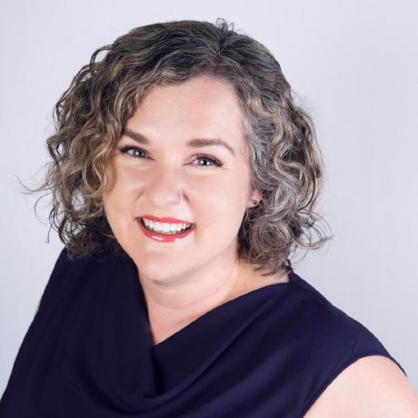

Will Landau

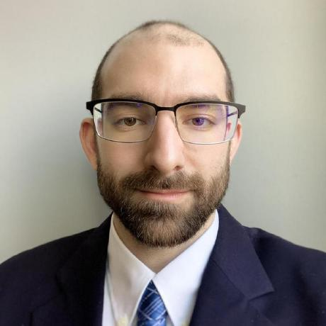

## Novedades (Español)

##### Divide y vencerás: de polar al Polarverse

2 ago 2024

##### Inscripción

2024

1 ago 2024

##### Llamado a Presentación de Trabajos

2024

9 jul 2024

##### Becas de asistencia

18 ago 2023

##### Inscripción

8 jun 2023

##### Conferencias

8 jun 2023

##### Llamado a Presentación de Trabajos

24 abr 2023

##### Llamado a Presentación de Trabajos

15 jun 2022

##### Creando presentaciones con el theme latinR

1 oct 2021

##### Llamado a Presentación de Trabajos

21 abr 2021

##### ReproHack en LatinR 2020

26 oct 2020

##### Comunidades de Práctica en América Latina: R y Colegas

8 jul 2020

##### LatinR 2020 será virtual!

14 may 2020

##### Paquete latinr para crear y enviar trabajos a LatinR

3 mar 2020

##### Conferencias de R en Latinoamerica durante el 2020

28 feb 2020

##### Llamado a Presentación de Trabajos

16 dic 2019

##### Código de Conducta del Slack LatinR

27 jul 2018

##### Código de Conducta

15 ene 2018

##### Atribuciones

11 ene 2018

## News (English)

##### Divide and Conquer: From polar To the Polarverse

2 ago 2024

##### Registration

2024

1 ago 2024

##### Call for papers

2024

9 jul 2024

##### Scholarships

18 ago 2023

##### Registration

8 jun 2023

##### Keynote speakers

8 jun 2023

##### Call for Papers

24 abr 2023

##### ReproHack in LatinR 2020

26 oct 2020

##### Latin American communities and organizations: useR!2020 video

8 jul 2020

##### LatinR 2020 will be a virtual event!

14 may 2020

##### The latinr package lets you create and submit presentations to LatinR

3 mar 2020

##### Birds of a feather, drawn together

29 feb 2020

##### R Conferences in Latin America during 2020

28 feb 2020

##### Call for Papers

16 dic 2019

##### LatinR Slack - Code of Conduct

27 jul 2018

##### Code of Conduct

15 ene 2018

##### Attributions

11 ene 2018

## Novidades (Português)

##### Divida e vencerá: de polar ao Polarverse

2 ago 2024

##### Inscrição

2024

1 ago 2024

##### Chamada de apresentação de trabalhos

2024

9 jul 2024

##### Bolsas de auxílio

18 ago 2023

##### Inscrição

8 jun 2023

##### Conferências

8 jun 2023

##### Chamada para submissão de trabalhos e tutoriais

24 abr 2023

##### Chamada para submissão de trabalhos e tutoriais

15 jun 2022

##### Pacote latinr para criar e enviar trabalhos para LatinR

3 mar 2020

##### Conferências de R na América Latina durante 2020

28 feb 2020

##### Chamada de Trabalhos

13 ene 2020

##### Código de conduta

15 ene 2018